# Project: Global Contraceptive Use vs Education Rates in Women

## As primary school completion rates for women increase, does contraceptive use among women also increase?

```python
# Open both data frames again

df_edu = education_mean_change
df_contra = contra_mean_change
```

```python
# merge datasets and rename columns
df_combined = df_edu.merge(df_contra, left_on='country', right_on='country')
df_edu.rename(columns={'1995': '1995_edu', '2015': '2015_edu'}, inplace=True)
df_contra.rename(columns={'1995': '1995_contra', '2015': '2015_contra'}, inplace=True)
```

```python
# check the header of the combined data frame for success
df_combined.head()
```

[output not shown]

### Now, to answer the final expoloratory question, I needed to visualize the combined data from education and contraceptive data sets.

## What is the correlation between rates of education and contraceptive use among women globally?

In order to address this analysis question, it was necessary to begin visualizing both sets of data, noting how they compared and contrasted.

First, I examined a histogram of both the mean change in contraceptive usage and education rates among women as they changed over time between 1995 - 2015.

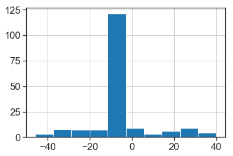

```python
df_combined.contra_change.hist();
```

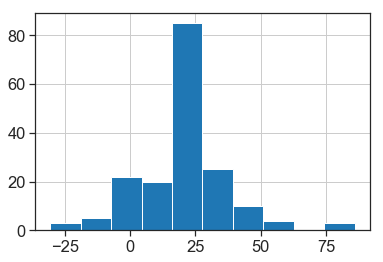

```python
df_combined.edu_change.hist();
```

## Next, I moved on to 2d visualizations of both variables in relationship to one another.

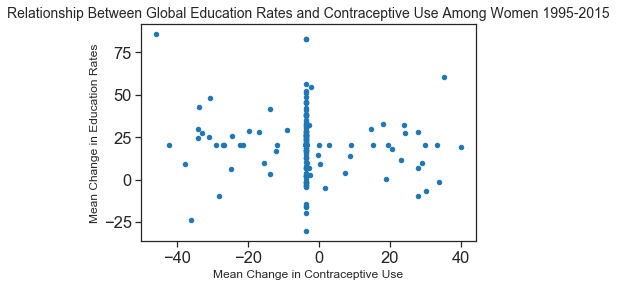

```python
df_combined.plot(kind='scatter', x='contra_change', y='edu_change')

plt.title('Relationship Between Global Education Rates and Contraceptive Use Among Women 1995-2015', fontsize=14)
# Set x-axis label
plt.xlabel('Mean Change in Contraceptive Use', fontsize=12)
# Set y-axis label
plt.ylabel('Mean Change in Education Rates', fontsize=12)

g.set(xticklabels=())
```

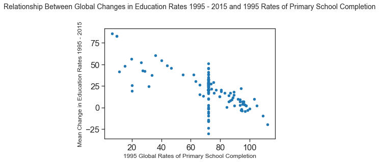

```python
# Find the correlation between 1995 education rates and the mean change in education rates between 1995 - 2015.


df_combined.plot(kind='scatter', x='1995_edu', y='edu_change')

plt.title('Relationship Between Global Changes in Education Rates 1995 - 2015 and 1995 Rates of Primary School Completion\n\n', fontsize=14)
# Set x-axis label
plt.xlabel('1995 Global Rates of Primary School Completion', fontsize=12)
# Set y-axis label
plt.ylabel('Mean Change in Education Rates 1995 - 2015', fontsize=12)

g.set(xticklabels=())
```

The scatterplot above indicates a negative relationship between global women's primary school completion rates in 1995 as compared to the mean change in education rates globally for women between 1995 - 2015. In other words, it could be extrapolated that with 1995 being the baseline for the measurement of these changes over 20 years' time, global rates in education for women have increased as compared to the 1995 baseline.

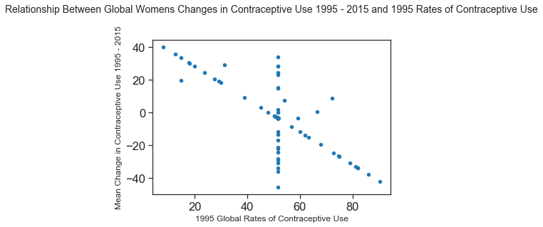

```python
# Find the correlation between 1995 contraceptive rates and the mean change in contraceptive use between 1995 - 2015.

df_combined.plot(kind='scatter', x='1995_contra', y='contra_change')

plt.title('Relationship Between Global Womens Changes in Contraceptive Use 1995 - 2015 and 1995 Rates of Contraceptive Use\n\n', fontsize=14)
# Set x-axis label
plt.xlabel('1995 Global Rates of Contraceptive Use', fontsize=12)
# Set y-axis label
plt.ylabel('Mean Change in Contraceptive Use 1995 - 2015', fontsize=12)

g.set(xticklabels=())
```

## Conclusions

### Limitations

These visualizations do not seem to be limited by a small population, as they are based on statistics from within a number of different countries globally over several decades. One potential limition, however, might be the question of whether this data is actually an accurate representation of the population. There is no imformation available on this data set that would speak to the data collection methodology, who was targeted for data collection, when or why.

## Submitting your Project

> Before you submit your project, you need to create a .html or .pdf version of this notebook in the workspace here. To do that, run the code cell below. If it worked correctly, you should get a return code of 0, and you should see the generated .html file in the workspace directory (click on the orange Jupyter icon in the upper left).

> Alternatively, you can download this report as .html via the **File** > **Download as** submenu, and then manually upload it into the workspace directory by clicking on the orange Jupyter icon in the upper left, then using the Upload button.

> Once you've done this, you can submit your project by clicking on the "Submit Project" button in the lower right here. This will create and submit a zip file with this .ipynb doc and the .html or .pdf version you created. Congratulations!

```python
from subprocess import call
call(['python', '-m', 'nbconvert', 'Investigate_a_Dataset.ipynb'])
```